# Twitter Analysis on Allergy

### This notebook pulls latest tweets on allergy, finds sentiment, most common words and plots tweeted user's location

Get twitter consumer key, secret, access token and access token secret for your twitter account and perform authentication

Get frequently used words in English, they will be removed from tweets

To get tweets within USA, use latitude and logitude of central USA and search within 1000 mile radius

```
100 (100, 6)
200 (200, 6)
Total tweets fetched for allergy: 200
Wall time: 1min 53s
```

Get latest 200 tweets and check first 5 records

|  | created_at | location | sentiment | text | lat | long |
| --- | --- | --- | --- | --- | --- | --- |
| 0 | 2019-03-30 22:44:06 | Sacramento | 1 | enjoying sping until her bff allergy smacks me in the face | 38.5794 | -121.491 |
| 1 | 2019-03-30 22:43:44 | Devon | -1 | and elvis is in agony again 10 days now all day hes 90 percent then screaming pain docs say food allergy possibly or trapped wind 10 days though weve eliminated milk chocolate and any crap just doesnt… | 50.753 | -3.81163 |
| 2 | 2019-03-30 22:43:07 | Calgary, Alberta | -1 | excuse me hives where how im out of allergy meds you fuck | 51.0453 | -114.063 |
| 3 | 2019-03-30 22:42:29 | Washington, DC | 0 | dont forget to take your allergy meds | 38.8904 | -77.032 |
| 4 | 2019-03-30 22:41:32 |  | 1 | getting my dog to take her allergy medicine is the most stressful thing ive ever had to do | None | None |

Check sentiment of tweets, whether they are positive, negative or neutral. Visualize their percentage as a pie chart with following sentiment-color combination.

Positive-Green, Negative-Red, Neutral-Yellow

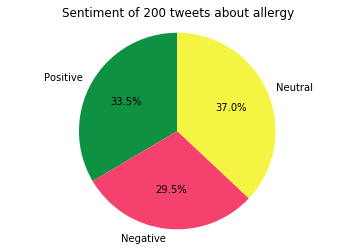

Common words found in Tweets (without stop words)

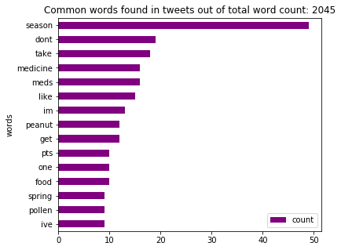

Get bigrams i.e, mostly used two word combinations in tweets and visualize network of bigrams

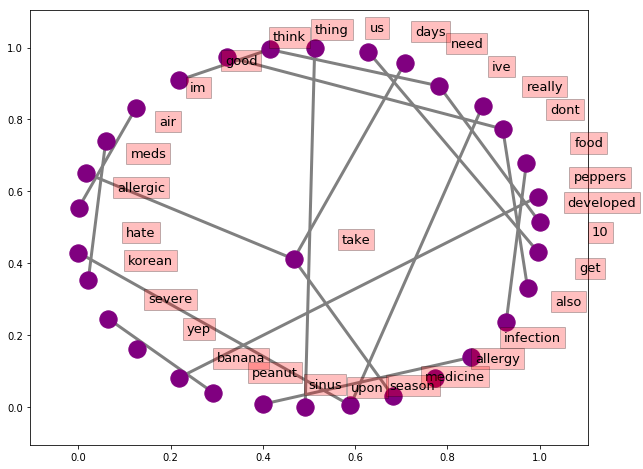

Plot tweeted user's location on USA geographical map with color same as sentiment as in pie chart and display tweeted text on hover.

[interactive chart not shown]

#### Based on negative sentiment tweets on the map, we can get location of allergy sufferers in general